# Question 1: Case Study (4 points):

To encourage some early attention to the case study deliverable that is due on Feb 21, write a brief summary of your initial thoughts for your case study. Include details about your topic, and sources of literature that you’re considering to review, and provide examples/motivation. Note: You will not be penalized if you change your mind about the topic or literature in the time between this submission and your final case study report.

Ans: Topic: YoutubeMusic Recommendation System

I selected this topic as I have used many music streaming apps and have found that YTmusic have The best recommendation algorithm of all. In my case study, I’ll be discussing music recommendation algorithm From a couple of music streaming apps and then compare them to see why YTmusic performs better.

Below are some literature sources that I’ll be referencing:

1. Thierry Bertin-Mahieux, Daniel P.W. Ellis, Brian Whitman, and Paul Lamere. The million song dataset. In Proceedings of the 11th International Conference on Music Information Retrieval (ISMIR), 2011.
2. Deep content-based music recommendation A¨ aron van den Oord, Sander Dieleman, Benjamin Schrauwen Electronics and Information Systems department (ELIS), Ghent University aaron.vandenoord, sander.dieleman, benjamin.schrauwen
3. A Critical Analysis of Music Recommendation Systems and New Perspectives | SpringerLink
4. Music Recommendations: Algorithms, Practical Challenges and Applications (researchgate.net)
5. Deep Neural Networks for YouTube Recommendations Paul Covington, Jay Adams, Emre Sargin Google Mountain View, CA

# Q2

Linear Regression: In this section, you are to perform comparative analysis on linear regression models to predict the Ames housing price. The Ames Housing dataset describes the sale of individual residential properties in Ames, Iowa from 2006 to 2010. The target variable is 'SalePrice'. The feature set comprises a large number of explanatory variables involved in assessing home values.

# a)

Handling null values: Print the number of rows and columns. Find the features in the dataset that have more than 70% null values and remove them from the dataset. What features did you remove? How many features with null values remain? (3 points)

```python
import pandas as pd
import numpy as np
```

```python
from sklearn.datasets import fetch_openml
housing = fetch_openml(name="house_prices", as_frame=True)
print("\nThe row and column details for the dataset are:")
print("number of rows: "+ str(housing.data.shape[0]))
print("number of columns: "+ str(housing.data.shape[1]))
```

```
The row and column details for the dataset are:
number of rows: 1460
number of columns: 80
```

```python
print("\nThe columns with more than 70% NULL values are:")

print("Alley,FireplaceQu, PoolQC,Fence, MiscFeature. \n\nDropping these columns.")
housing.data.drop(columns=["Alley", "FireplaceQu", "PoolQC","Fence","MiscFeature"])

#making copy of the dataset and encoding string variables
cleaned_df = housing.data
for col_name in cleaned_df.columns:
    if(cleaned_df[col_name].dtype == 'object'):
        cleaned_df[col_name]= cleaned_df[col_name].astype('category')
        cleaned_df[col_name] = cleaned_df[col_name].cat.codes

cleaned_df=cleaned_df.interpolate()

#scaling down the salesprice
y = housing.target/1000
print("\nAfter dropping NULL columns, now only 15 columns with some null values are left")
```

[output not shown]

# b.

Divide the dataset into train, validate and test (60% train, 20% validate, 20% test).

```python
from sklearn.model_selection import train_test_split

# First split the data into training (60%) and temporary (40%) sets
X_train, X_temp, y_train, y_temp = train_test_split(cleaned_df, y, test_size=0.4, random_state=42)

# Then split the temporary set into validation (20%) and testing (20%) sets
X_val, X_test, y_val, y_test = train_test_split(X_temp, y_temp, test_size=0.5, random_state=42)

print("Sizes of the datatsets (row,column) are as below:\n")

print("X_train"+ str(X_train.shape))
print("X_temp"+ str(X_temp.shape))

print("y_train"+ str(y_train.shape))
print("y_temp"+ str(y_temp.shape))

print("X_val"+ str(X_val.shape))
print("X_test"+ str(X_test.shape))

print("y_val"+ str(y_val.shape))
print("y_test"+ str(y_test.shape))
```

```
Sizes of the datatsets (row,column) are as below:

X_train(876, 80)
X_temp(584, 80)
y_train(876,)
y_temp(584,)
X_val(292, 80)
X_test(292, 80)
y_val(292,)
y_test(292,)
```

# c)

Print out the correlation matrix of the features. How many features are highly correlated with each other? Are there any features correlated with the target variable (let’s define highly correlated as >=0.75?). Use only the training set for correlation analysis to avoid data leakage (2 points)

```python
#combining the training datasets x-train and y
X_train['target'] = y
```

```python
import seaborn as sns
import matplotlib.pyplot as plt

def show_heatmap(correlation_matrix):
  # Set the figure size (optional)
  plt.figure(figsize=(30, 24))

  # Generate the correlation matrix heatmap
  sns.heatmap(correlation_matrix, cmap='coolwarm', annot=True, fmt=".2f", linewidths=0.5)

  # Set the title and labels
  plt.title('Correlation Matrix')
  plt.xlabel('Variables')
  plt.ylabel('Variables')

  # Display the heatmap
  plt.show()
```

```python
import seaborn as sns

# Calculate the correlation
correlation_matrix = cleaned_df.corr().abs()

# Select upper triangle of correlation matrix
mask = np.triu(np.ones(correlation_matrix.shape), k=1).astype(bool)
mask = np.triu(np.ones_like(correlation_matrix, dtype=bool))
upper = correlation_matrix.where(mask)
```

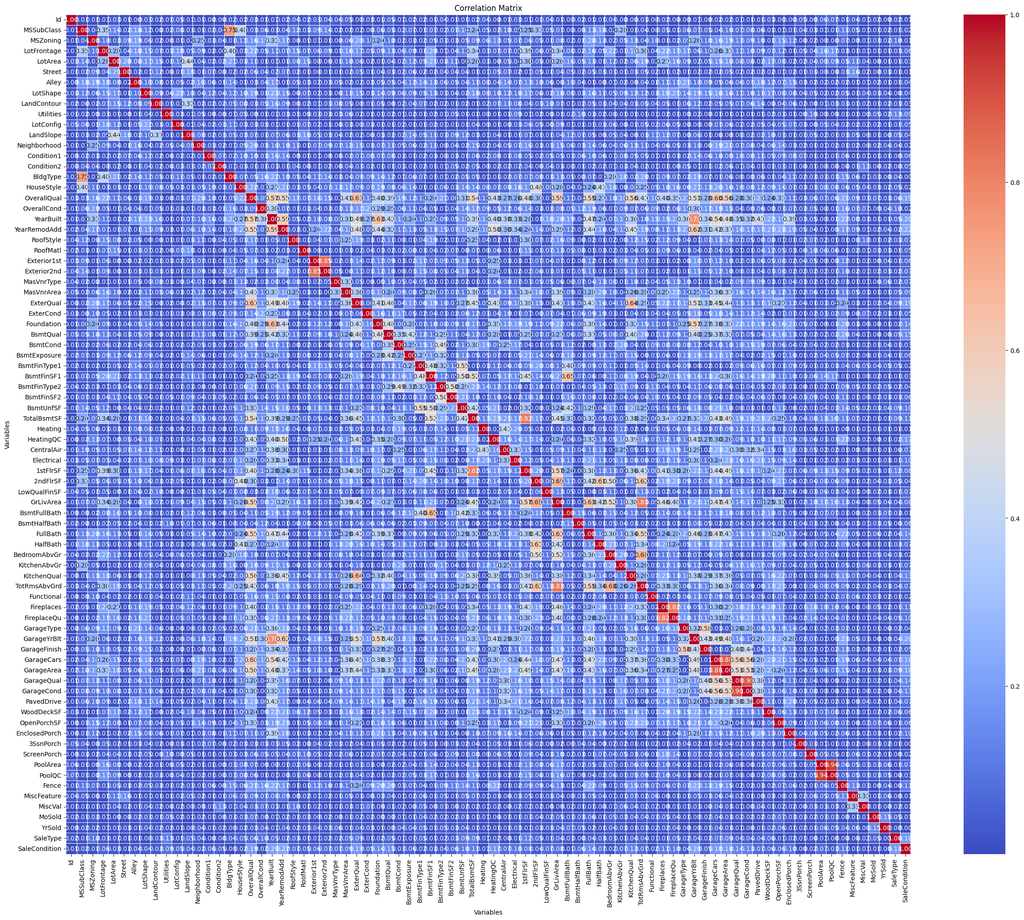

```python
show_heatmap(correlation_matrix)
```

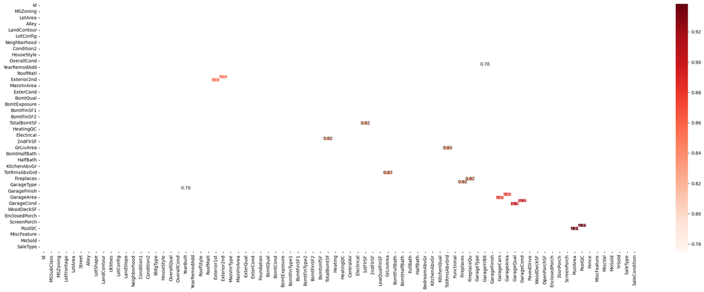

```python
import seaborn as sn

#checking highly correlated variables
filteredDf = correlation_matrix[((correlation_matrix >= .75) | (correlation_matrix <= -.75)) & (correlation_matrix !=1.000)]

plt.figure(figsize=(30,10))

sn.heatmap(filteredDf, annot=True, cmap="Reds")

plt.show()
```

```python
xFlattened = filteredDf.unstack().sort_values().drop_duplicates()

print("Highly correlated variables are:\n")
xFlattened
```

```
Highly correlated variables are:
```

```
YearBuilt    GarageYrBlt     0.775012
TotalBsmtSF  1stFlrSF        0.819530
Fireplaces   FireplaceQu     0.824059
GrLivArea    TotRmsAbvGrd    0.825489
Exterior1st  Exterior2nd     0.854163
GarageCars   GarageArea      0.882475
GarageQual   GarageCond      0.902991
PoolArea     PoolQC          0.938402
Id           Id                   NaN
dtype: float64
```

# d)

Prevent collinearity by removing linearly dependent variables from the train set. (1 points) For example, if 2 variables A and B have a correlation coefficient larger than or equal to 0.75, eliminate one to avoid redundancy.

```python
#dropping the highly correlated
X_train=X_train.drop(['MSSubClass','target','PoolQC','GarageQual','Exterior2nd','FireplaceQu','GarageYrBlt','TotRmsAbvGrd'], axis=1)
```

# e)

Remove the features identified from the previous question from your validation and test sets as well. (Note: no additional correlation analysis is required at this point) (1 point

```python
X_val= X_val.drop(['MSSubClass','PoolQC','GarageQual','Exterior2nd','FireplaceQu','GarageYrBlt','TotRmsAbvGrd'], axis=1)
```

```python
X_test = X_test.drop(['MSSubClass','PoolQC','GarageQual','Exterior2nd','FireplaceQu','GarageYrBlt','TotRmsAbvGrd'], axis=1)
```

## Simple Linear Regression: Model 1

The goal of simple linear regression is to create a linear model that predicts the dependent variable as accurately as possible as a function of the independent variable. The mathematical equation for a simple linear regression is: y = β0 + β1*x + ε where: y is the dependent variable (also known as the 'outcome', 'target' or 'response' variable), x is the independent variable (also known as the 'predictor', 'explanatory' or 'input' variable), β0 is the y-intercept of the regression line (the value of y when x = 0), β1 is the slope of the regression line (for each one-unit increase in x, y increases by β1 units), and ε is the random error term which is assumed to be normally distributed with a mean of 0. The aim of simple linear regression is to find the best estimates for the parameters β0 and β1 that minimize the sum of the squared residuals, where a residual is the difference between the actual y value and the predicted y value for each observation

## Question 3: (12 points)

Let's look at "GrLivArea" feature, which stands for "Above grade (ground) living area square feet". This variable measures the total area of livable (habitable) space above ground. It makes intuitive sense that this would be a good predictor of the price of a house, as larger houses generally tend to be more expensive.

# a)

Create a scatter plot of SalePrice vs GrLivArea

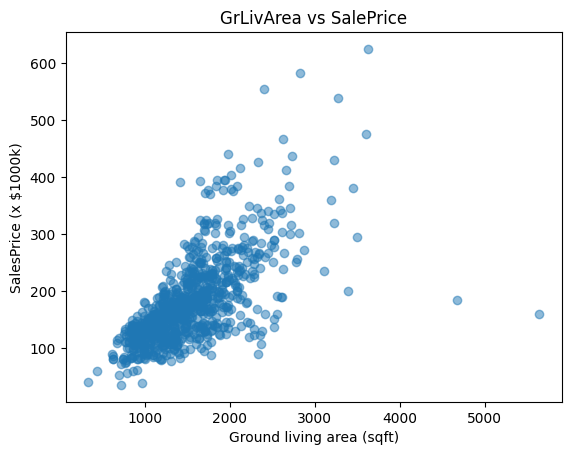

```python
plt.scatter(X_train['GrLivArea'],y_train, alpha=0.5)
plt.ylabel("SalesPrice (x $1000k)")
plt.xlabel("Ground living area (sqft)")
plt.title("GrLivArea vs SalePrice")
```

The observed trend indicates a positive correlation between the expansion of ground living area and the corresponding increase in apartment sales prices.

# b)

Fit a simple linear regression model on this variable. Print out the model summary

```python
from sklearn.linear_model import LinearRegression
from sklearn.metrics import mean_squared_error

X_train_mini = X_train[['GrLivArea']]
y_mini = y_train  # Target: Sale Price

# Create a linear regression model
model1 = LinearRegression()
# Fit the model on the training data
model1.fit(X_train_mini, y_mini)

# Print the coefficients and intercept
print("Model Summary:")
print("Coefficient:", model1.coef_[0])
print("Intercept:", model1.intercept_)
```

```
Model Summary:
Coefficient: 0.09514328806909014
Intercept: 35.085789046249175
```

# c)

Create a new scatter plot with the regression line that you just modeled

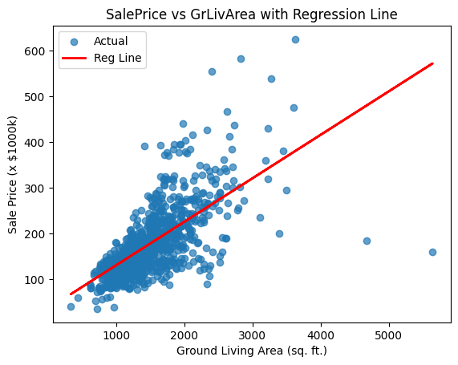

```python
# Make predictions using the fitted model
y_preds_mini = model1.predict(X_train_mini)

# Create a scatter plot of GrLivArea vs SalePrice
plt.scatter(X_train_mini, y_mini, label='Actual', alpha=0.7)
plt.plot(X_train_mini, y_preds_mini, color='red', linewidth=2, label='Reg Line')

plt.title('SalePrice vs GrLivArea with Regression Line')
plt.xlabel('Ground Living Area (sq. ft.)')
plt.ylabel('Sale Price (x $1000k)')

# Add a legend
plt.legend()

# Display the plot
plt.show()
```

# d)

Evaluate the prediction performance of the model on the validation set with RMSE and MAE as performance metrics.

```python
X_val_mini = X_val[['GrLivArea']]

from sklearn.metrics import mean_squared_error, mean_absolute_error


# Make predictions on the validation set
y_val_preds_mini = model1.predict(X_val_mini)

# Compute Mean Absolute Error (MAE)
mae = mean_absolute_error(y_val, y_val_preds_mini)
print(f"Validation Set output: Mean Absolute Error (MAE): {mae}")

# Compute Root Mean Squared Error (RMSE)
mse = mean_squared_error(y_val, y_val_preds_mini)
rmse = np.sqrt(mse)
print(f"Validation Set output: Root Mean Squared Error (RMSE): {rmse}")

model1_square  = model1.score(X_val_mini, y_val)
print('Validation Set output: R-squared score : ', model1_square)
```

```
Validation Set output: Mean Absolute Error (MAE): 42.537822715857736
Validation Set output: Root Mean Squared Error (RMSE): 65.94676454242591
Validation Set output: R-squared score :  0.5381896624482657
```

# e)

Evaluate the prediction performance of the model on the test set with RMSE and MAE as performance metrics. Choose a random data point from the test set and perform a prediction using the model.

```python
X_test_mini = X_test[['GrLivArea']]
y_test_preds_mini = model1.predict(X_test_mini)

# Compute Mean Absolute Error (MAE)
mae1 = mean_absolute_error(y_test, y_test_preds_mini)
print(f"Test Set output: Mean Absolute Error (MAE): {mae}")

# Compute Root Mean Squared Error (RMSE)
mse1 = mean_squared_error(y_test, y_test_preds_mini)
rmse1 = np.sqrt(mse1)

print(f"Test Set output: Root Mean Squared Error (RMSE): {rmse1}")

model1_square  = model1.score(X_test_mini, y_test)
print('Test Set output: R-squared score : ', model1_square)
```

[output not shown]

# f)

Summarize your findings in your own words, and compare results from the validation set and test set on this simple linear regression model

## Multiple Linear Regression: Model 2

Multiple linear regression is an extension of simple linear regression used to predict an outcome variable based on several predictor variables. The predictor variables in multiple linear regression can be continuous, categorical, or a mix of both. y = β0 + β1*x1 + β2*x2 + ... + βn*xn + ε

## Question 4:

## a)

Consider all the features (after removing linearly dependent variables in question 1. Ensure that all of your features are numeric and that they have been properly preprocessed (e.g., missing values have been handled, categorical features have been encoded etc. When appropriate, describe briefly the methods you use to handle features.

```python
X_train.info()
print("\nWe can see that our features are properply processed and no unprocessed categorcial feature is present with any NULL values")
```

```
<class 'pandas.core.frame.DataFrame'>
Index: 876 entries, 314 to 1126
Data columns (total 73 columns):
 #   Column         Non-Null Count  Dtype
---  ------         --------------  -----
 0   Id             876 non-null    int64
 1   MSZoning       876 non-null    int8
 2   LotFrontage    876 non-null    float64
 3   LotArea        876 non-null    int64
 4   Street         876 non-null    int8
 5   Alley          876 non-null    int8
 6   LotShape       876 non-null    int8
 7   LandContour    876 non-null    int8
 8   Utilities      876 non-null    int8
 9   LotConfig      876 non-null    int8
```

[output cut: 67 more lines]

# b.

Fit a linear regression model on the training set with a package of your choice. Present the model summary.

```python
# Import necessary libraries

from sklearn.model_selection import train_test_split
from sklearn.ensemble import HistGradientBoostingRegressor
from sklearn.metrics import mean_squared_error



# Create a Histogram-based Gradient Boosting Regressor
model = HistGradientBoostingRegressor()

# Train the model on the training data
model.fit(X_train, y_train)

# Make predictions on the test data
y2_pred = model.predict(X_test)

# Evaluate the model
mse2 = mean_squared_error(y_test, y2_pred)
print(f'Mean Squared Error: {mse}')
```

[output not shown]

# c)

Evaluate the model on both the validation and test sets. Print out the coefficient of determination (R**2) and MSE for both sets. What are the most important features?

```python
# Import necessary libraries

from sklearn.model_selection import train_test_split
from sklearn.experimental import enable_hist_gradient_boosting  # noqa
from sklearn.ensemble import HistGradientBoostingRegressor
from sklearn.impute import SimpleImputer
from sklearn.metrics import r2_score, mean_squared_error


# Create a Histogram-based Gradient Boosting Regressor
model2 = LinearRegression()

# Train the model on the training data
model2.fit(X_train, y_train)

# Make predictions on the validation and test data
y_valid_pred = model2.predict(X_val)
y_test_pred = model2.predict(X_test)

# Evaluate the model on the validation set
r2_valid = r2_score(y_val, y_valid_pred)
mse_valid = mean_squared_error(y_val, y_valid_pred)
print(f'Validation Set - R^2: {r2_valid:.4f}')
print(f'Validation Set, MSE: {mse_valid:.4f}')

# Evaluate the model on the test set
r2_test = r2_score(y_test, y_test_pred)
mse_test = mean_squared_error(y_test, y_test_pred)
print(f'Test Set - R^2: {r2_test:.4f}')
print(f'Test Set, MSE: {mse_test:.4f}')
```

```
Validation Set - R^2: 0.8045
Validation Set, MSE: 1840.8871
Test Set - R^2: 0.8333
Test Set, MSE: 815.0569
```

```python
coef_df = pd.DataFrame({'feature': X_test.columns,'coefficient': model.coef_})

# Sort by absolute value of coefficient
coef_df['abs_coefficient'] = coef_df['coefficient'].abs()
coef_df = coef_df.sort_values('abs_coefficient', ascending=False)
coef_df.head(10)
```

[output not shown]

The Above features are the 10 most important features according to the Coefficient of determination.

# Question 5: (12 points) Model 3

Variable Selection with Regularization: Now consider all the features (after removing linearly dependent variables).

# a.

Fit a LASSO linear regression model on the training set with a package at your choice.

# b.

Compare the model performance of lambda in the range of [0,1] with a step of 0.01. Plot RMSE versus log(lambda).

```python
from sklearn.impute import SimpleImputer
from sklearn.preprocessing import OneHotEncoder

#new dataset to avoid confusion
housing2 = fetch_openml(name="house_prices", as_frame=True)
X2 = pd.DataFrame(data = housing2.data, columns = housing2.feature_names)
y2 = housing2['target']
column_name = 'target'

if column_name in X2.columns:
    print(f"{column_name} is in the DataFrame. Dropping the response variable")
    X2 = X2.drop(columns=[column_name])
else:
    print(f"{column_name} is NOT in the DataFrame.")

# Identify numeric columns
nf = X2.select_dtypes(include=['int64', 'float64']).columns

#using median method for imputer
imputer = SimpleImputer(strategy='median')
X2[nf] = imputer.fit_transform(X2[nf])

cf = X2.select_dtypes(include=['object', 'category']).columns
cf
```

```
target is NOT in the DataFrame.
```

```
Index(['MSZoning', 'Street', 'Alley', 'LotShape', 'LandContour', 'Utilities',
       'LotConfig', 'LandSlope', 'Neighborhood', 'Condition1', 'Condition2',
       'BldgType', 'HouseStyle', 'RoofStyle', 'RoofMatl', 'Exterior1st',
       'Exterior2nd', 'MasVnrType', 'ExterQual', 'ExterCond', 'Foundation',
       'BsmtQual', 'BsmtCond', 'BsmtExposure', 'BsmtFinType1', 'BsmtFinType2',
       'Heating', 'HeatingQC', 'CentralAir', 'Electrical', 'KitchenQual',
       'Functional', 'FireplaceQu', 'GarageType', 'GarageFinish', 'GarageQual',
       'GarageCond', 'PavedDrive', 'PoolQC', 'Fence', 'MiscFeature',
       'SaleType', 'SaleCondition'],
      dtype='object')
```

```python
# For categorical columns, use mode (most frequent value) to replace missing values
imputer = SimpleImputer(strategy='most_frequent')
X2[cf] = imputer.fit_transform(X2[cf])

# One-hot encode the categorical columns
encoder = OneHotEncoder(handle_unknown='ignore', sparse=False)
X2_encoded = pd.DataFrame(encoder.fit_transform(X2[cf]))
X2_encoded.columns = encoder.get_feature_names_out(cf)

# Drop original categorical columns and add the encoded ones
X2.drop(cf, axis=1, inplace=True)
X2 = pd.concat([X2, X2_encoded], axis=1)

# First split the data into training (60%) and temporary (40%) sets
X2_train, X2_temp, y2_train, y2_temp = train_test_split(X2, y2, test_size=0.4, random_state=42)

# Then split the temporary set into validation (20%) and testing (20%) sets
X2_val, X2_test, y2_val, y2_test = train_test_split(X2_temp, y2_temp, test_size=0.5, random_state=42)

columns_with_missing_values = X2.columns[X2.isnull().sum() > 0]
```

```python
from sklearn.linear_model import Lasso
from sklearn.preprocessing import StandardScaler

# Preprocess the predictors
scaler = StandardScaler()
X2_train_scaled = scaler.fit_transform(X2_train)
X2_val_scaled = scaler.fit_transform(X2_val)
X2_test_scaled = scaler.transform(X2_test)
```

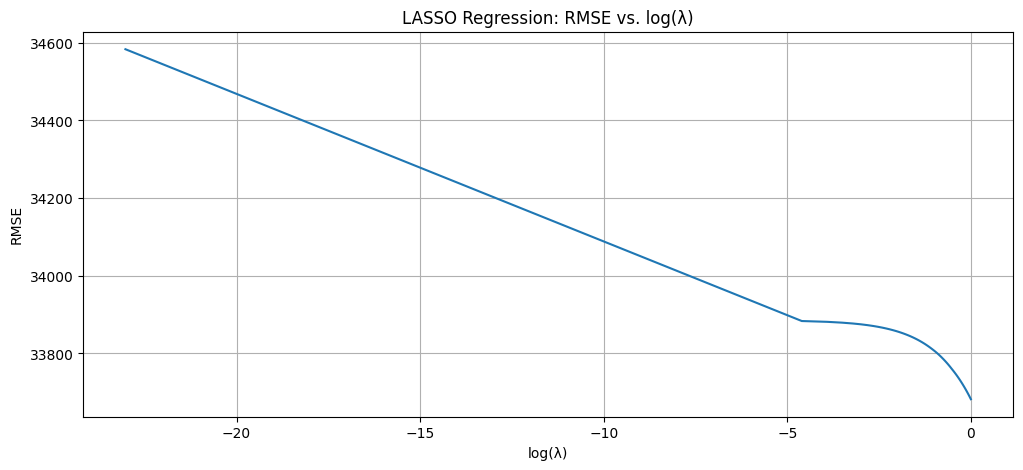

```python
# Define the range of lambda values to test
lambda_values = np.arange(0, 1.01, 0.01)

# Initialize lists to store RMSE values
rmse_values = []

# Loop over lambda values, fit a LASSO model, and calculate RMSE
for lambda_val in lambda_values:
    lasso = Lasso(alpha=max(lambda_val, 1e-10), max_iter=100000, random_state=42)

    # Fit the model on the training data
    lasso.fit(X2_train, y2_train)

    # Predict on the validation set
    y_pred = lasso.predict(X2_val)

    # Calculate RMSE and append to the list
    rmse = np.sqrt(mean_squared_error(y2_val, y_pred))
    rmse_values.append(rmse)

# Plot RMSE vs log(lambda)
plt.figure(figsize=(12, 5))
plt.plot(np.log(lambda_values + 1e-10), rmse_values)
plt.xlabel('log(λ)')
plt.ylabel('RMSE')
plt.title('LASSO Regression: RMSE vs. log(λ)')
plt.grid(True)
plt.show()
```

# c.

Pick the appropriate lambda value according to the plot.

Ans: The appropriate Lambda value according to the Plot is 1 as the lowest RMSE value is at Lambda=1

# d.

Present the model summary with the selected lambda. We call this model Model 3.

# e.

Choose a random data point from the test set and perform a prediction using the model. What are your findings in comparison to the actual Sale Price?

```python
# Choose a random data point from the test set

import random
index = random.randint(0, len(X2_test_scaled)-1)
data_point = X2_test_scaled[index]
print("Index of the randomly selected data point is: "+str(index))

# Reshape the data point
data_point = data_point.reshape(1,-1)

# Perform prediction using the Lasso model
prediction = lasso.predict(data_point)

print(f'The predicted value for the selected house is: {abs(prediction[0]/10)}, actual sales price is: {list(y2_test)[index]}')
```

```
Index of the randomly selected data point is: 72
The predicted value for the selected house is: 79199.21453532894, actual sales price is: 86000
```

# f.

Evaluate the prediction performance of Model 3 on the validation set with RMSE and MAE as performance metrics.

```python
# Recreating the LASSO linear regression model with lambda = 1 for the next steps
lasso_model = Lasso(alpha=1.0)

# Adjust the regularization parameter (alpha) as needed
lasso_model.fit(X2_train_scaled, y2_train)

# Print the model summary
print("Intercept:", lasso_model.intercept_)
y2_lasso_pred = lasso_model.predict(X2_val_scaled)
y2_lasso_test_pred =lasso_model.predict(X2_test_scaled)
```

```
Intercept: 179921.7865296804
```

```python
# Compute Mean Absolute Error (MAE)
mae_lasso = mean_absolute_error(y2_val, y2_lasso_pred)
print(f"Mean Absolute Error (MAE) for Model3: {mae_lasso}")

# Compute Root Mean Squared Error (RMSE)
mse_lasso = mean_squared_error(y2_val, y2_lasso_pred)
rmse_lasso = np.sqrt(mse_lasso)
print(f"Root Mean Squared Error (RMSE) for Model3: {rmse_lasso}")

model_lasso_square  = lasso_model.score(X2_val_scaled, y2_val)
print('R-squared score model3 : ', model_lasso_square)
```

```
Mean Absolute Error (MAE) for Model3: 22443.054523872044
Root Mean Squared Error (RMSE) for Model3: 37258.72985626763
R-squared score model3 :  0.8525880281736685
```

Our R^2 value came to be around 85% which is a good improvement from the last linear rgression model which we had.

## Question 6: (8 points)

# a)

Compare the validation set performance of Model 1, Model 2 and Model 3

```python
# Compute Mean Absolute Error (MAE)
mae2 = mean_absolute_error(y2_val, y2_pred)
print(f"Validation set Mean Absolute Error (MAE) for Model2: {mae2}")

# Compute Root Mean Squared Error (RMSE)
mse2 = mean_squared_error(y2_val, y2_pred)
rmse2 = np.sqrt(mse2)
print(f"Validation set Root Mean Squared Error (RMSE) for Model2: {rmse2}")

model2.fit(X2_val,y2_val)
model2_square  = model2.score(X2_val, y2_val)
print('Validation set R-squared score model2 : ', model2_square)
```

```
Validation set Mean Absolute Error (MAE) for Model2: 191926.17019685736
Validation set Root Mean Squared Error (RMSE) for Model2: 215066.1798235896
Validation set R-squared score model2 :  0.9780181854846055
```

```python
print(f"Validation set Mean Absolute Error (MAE) by model: {mae1*1000}     {mae2}     {mae_lasso}")
print(f"Validation set Root Mean Squared Error (RMSE): {rmse1}    {rmse2}     {rmse_lasso} ")
print('Validation set R-squared score : ', model1_square, model2_square, model_lasso_square)
```

[output not shown]

```python
# Compare performance
if min(mae1*1000,mae2,mae_lasso) == mae1:
    print("Model 1 performs better.")
elif min(mae1*1000,mae2,mae_lasso) == mae2:
    print("Model 2 performs better.")
elif min(mae1*1000,mae2,mae_lasso) == mae_lasso:
    print("Model 3 performs better.")
```

```
Model 3 performs better.
```

# b)

Compare the test set performance of Model 1, Model 2 and Model 3.

```python
# Compute Mean Absolute Error (MAE)
mae2 = mean_absolute_error(y2_test, y2_pred)
print(f"Test set Mean Absolute Error (MAE): {mae2}")

# Compute Root Mean Squared Error (RMSE)
mse2 = mean_squared_error(y2_test, y2_pred)
rmse2 = np.sqrt(mse2)
print(f"Test set Root Mean Squared Error (RMSE): {rmse2}")

model2.fit(X2_test,y2_test)
model2_square  = model2.score(X2_test, y2_test)
print('Test set R-squared score model2 : ', model2_square)
```

```
Test set Mean Absolute Error (MAE): 172565.83800507654
Test set Root Mean Squared Error (RMSE): 186172.69490671807
Test set R-squared score model2 :  0.9793284800458611
```

```python
print(f"Test set Mean Absolute Error (MAE) by model: {mae1*1000}     {mae2}     {mae_lasso}")
```

[output not shown]

```python
# Compare performance
if min(mae1*1000,mae2,mae_lasso) == mae1:
    print("Model 1 performs better.")
elif min(mae1*1000,mae2,mae_lasso) == mae2:
    print("Model 2 performs better.")
elif min(mae1*1000,mae2,mae_lasso) == mae_lasso:
    print("Model 3 performs better.")
```

```
Model 3 performs better.
```

# c)

Visualize the prediction error on the test set of all models using histograms.

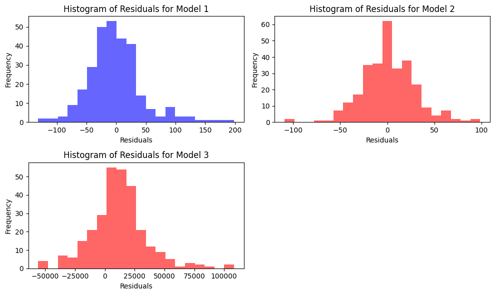

```python
residual_1= y_test - y_test_preds_mini
residual_2= y_test - y_test_pred
residual_3= y2_test - y2_lasso_test_pred

# Plot histogram
plt.figure(figsize=(10,6))

plt.subplot(2, 2, 1)
plt.hist(residual_1, bins=20, color='blue', alpha=0.6)
plt.title('Histogram of Residuals for Model 1')
plt.xlabel('Residuals')
plt.ylabel('Frequency')

plt.subplot(2, 2, 2)
plt.hist(residual_2, bins=20, color='red', alpha=0.6)
plt.title('Histogram of Residuals for Model 2')
plt.xlabel('Residuals')
plt.ylabel('Frequency')

plt.subplot(2, 2, 3)
plt.hist(residual_3, bins=20, color='red', alpha=0.6)
plt.title('Histogram of Residuals for Model 3')
plt.xlabel('Residuals')
plt.ylabel('Frequency')

plt.tight_layout()
plt.show()
```

# d)

Compare and contrast the model fitting.

# Classification using K-Nearest Neighbors

We will look at a classification task in this section. The classification task aims to assign predefined labels to objects (instances) based on their features. In the case of the k-NN algorithm, the label of an unseen instance is predicted based on the majority label of its k nearest neighbors in the feature space. Let us consider the tf_flowers dataset from the tensorflow datasets package. tf_flowers is a data set of 3,670 photos of flowers. The task is to classify these photos into the correct classes.

## Preprocessing (4 pts):

1. How many classes of flowers are included in the dataset? What are they?
2. Load the tf_flowers dataset and split it into a training set (60%), validation set (20%), and test set (20%). Make sure you set the seed as described below for reproducibility tf.random.set_seed(42)
3. The images are of different sizes. Resize all images to have the same dimension of 64×64.
4. Normalize the pixel values of the images to be between 0 and 1.

```python
import numpy as np
import os
import PIL
import PIL.Image
import tensorflow as tf
import tensorflow_datasets as tfds
```

```python
import tensorflow_datasets as tfds

# Retrieve information about the 'tf_flowers' dataset
flower_dataset = tfds.builder('tf_flowers').info

# Determine the total number of categories
total_categories = flower_dataset.features['label'].num_classes

# Retrieve the names of the categories, if they exist
category_labels = flower_dataset.features['label'].names

print("Number of classes:", total_categories)
print("Class names are:", category_labels)
```

```
Number of classes: 5
Class names are: ['dandelion', 'daisy', 'tulips', 'sunflowers', 'roses']
```

```python
import tensorflow as tf
import tensorflow_datasets as tfds

# Initialize random seed for consistent data shuffling and transformations
tf.random.set_seed(42)

# Configuration of dataset partitions
partitions = {
    'training_set': 'train[:60%]',
    'validation_set': 'train[60%:80%]',
    'testing_set': 'train[80%:]'
}

# Retrieve dataset according to partitions with labels
train = tfds.load('tf_flowers', split=partitions['training_set'], as_supervised=True)
validate = tfds.load('tf_flowers', split=partitions['validation_set'], as_supervised=True)
test = tfds.load('tf_flowers', split=partitions['testing_set'], as_supervised=True)

# Calculate the number of samples in each partition
count_train = len(list(train))
count_validation = len(list(validate))
count_test = len(list(test))

print(f"Training set size: {count_train}")
print(f"Validation set size: {count_validation}")
print(f"Test set size: {count_test}")
```

```
WARNING:tensorflow:From C:\Users\ankur\AppData\Local\Programs\Python\Python310\lib\site-packages\keras\src\losses.py:2976: The name tf.losses.sparse_softmax_cross_entropy is deprecated. Please use tf.compat.v1.losses.sparse_softmax_cross_entropy instead.
```

```
Training set size: 2202
Validation set size: 734
Test set size: 734
```

# c)

The images are of different sizes. Resize all images to have the same dimension of 64×64.

# d)

Normalize the pixel values of the images to be between 0 and 1.

# e)

k-NN Classification (6 pts): e. Flatten the images so that each image is represented as a 1D array, and then fit the k-NN algorithm on the training set. [Hint: KNeighborsClassifier from scikit-learn].

```python
import tensorflow as tf
import tensorflow_datasets as tfds
from sklearn.neighbors import KNeighborsClassifier
from sklearn.metrics import accuracy_score

# Function to resize and normalize images
def preprocess_image(image, label):
    # Resize image to 64x64
    image = tf.image.resize(image, (64, 64))
    # Normalize pixel values to [0, 1]
    image = tf.cast(image, tf.float32) / 255.0
    return image, label

# Apply preprocessing to resize and normalize images
train_pre = train.map(preprocess_image)
validate_pre = validate.map(preprocess_image)
test_pre = test.map(preprocess_image)

# Flatten the images in the training set
def flatten_image(image, label):
    image_flat = tf.reshape(image, [-1])
    return image_flat, label

train_flat = train_pre.map(flatten_image)
validate_flat = validate_pre.map(flatten_image)
test_flat = test_pre.map(flatten_image)

# Extract features and labels
train_images, train_labels = zip(*train_flat)
validate_images, validate_labels = zip(*validate_flat)
test_images, test_labels = zip(*test_flat)

# Fit k-NN algorithm on the training set
knn_classifier = KNeighborsClassifier(n_neighbors=3)  # You can adjust the number of neighbors
knn_classifier.fit(train_images, train_labels)

# Example: Evaluate on the validation set
validate_predictions = knn_classifier.predict(validate_images)
accuracy = accuracy_score(validate_labels, validate_predictions)
print(f"Accuracy on the validation set: {accuracy}")
```

```
Accuracy on the validation set: 0.3215258855585831
```

# f)

Perform hyperparameter tuning to find the best value of k (number of neighbors) using the validation set. Experiment with at least five different values of k and describe your approach to finding these 5 values briefly.

```python
# Hyperparameter tuning for k
best_k = None
best_accuracy = 0.0

# Experiment with at least five different values of k
for k in [3, 5, 7, 9, 11]:
    knn_classifier = KNeighborsClassifier(n_neighbors=k)
    knn_classifier.fit(train_images, train_labels)

    # Evaluate on the test set
    test_predictions = knn_classifier.predict(test_images)
    accuracy = accuracy_score(test_labels, test_predictions)

    print(f"Accuracy on the test set for k={k}: {accuracy}")

    # Update best_k if a higher accuracy is achieved
    if accuracy > best_accuracy:
        best_accuracy = accuracy
        best_k = k

print(f"\nBest k: {best_k} with accuracy on test set: {best_accuracy}")
```

```
Accuracy on the test set for k=3: 0.29155313351498635
Accuracy on the test set for k=5: 0.2888283378746594
Accuracy on the test set for k=7: 0.29427792915531337
Accuracy on the test set for k=9: 0.28610354223433243
Accuracy on the test set for k=11: 0.2888283378746594

Best k: 7 with accuracy on test set: 0.29427792915531337
```

# g)

Report the accuracy on the test set for each k and select the best one. Ans: The best accuracy is for the 7 neighbours.

```python
final_knn_classifier = KNeighborsClassifier(n_neighbors=best_k)
final_knn_classifier.fit(train_images, train_labels)
```

```
KNeighborsClassifier(n_neighbors=7)
```

## Model Evaluation (6 pts):

h. After selecting the best k, retrain your k-NN classifier using the training set.

i. Plot and explain the confusion matrix using the test set.

j. Select a random image from the test set, display it along with its true label, and predict its label using the k-NN classifier you trained.

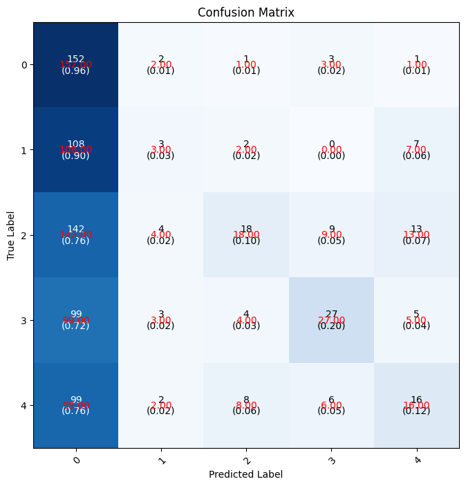

```python
import matplotlib.pyplot as plt
import numpy as np
from sklearn.metrics import confusion_matrix
from mlxtend.plotting import plot_confusion_matrix

# Function to plot and explain the confusion matrix as cm1
def cm1(model, test_images, test_labels):
    # Generate predictions on the test set
    predictions = model.predict(test_images)

    # Create a confusion matrix
    cm = confusion_matrix(test_labels, predictions)

    # Plot the confusion matrix
    class_names = np.unique(test_labels)
    fig, ax = plot_confusion_matrix(conf_mat=cm, figsize=(8, 8), class_names=class_names, show_normed=True)
    plt.title('Confusion Matrix')
    plt.xlabel('Predicted Label')
    plt.ylabel('True Label')

    # Add annotations
    for i in range(len(class_names)):
        for j in range(len(class_names)):
            ax.text(j, i, f"{cm[i, j]:.2f}", ha='center', va='center', color='red')

    plt.show()

# Plot and explain the confusion matrix using the final_knn_classifier and test set
cm1(final_knn_classifier, test_images, test_labels)
```

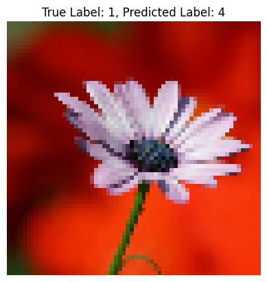

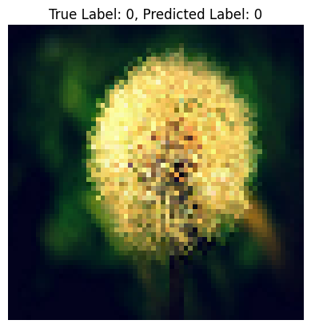

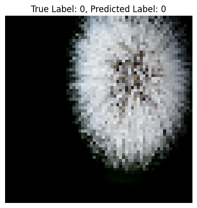

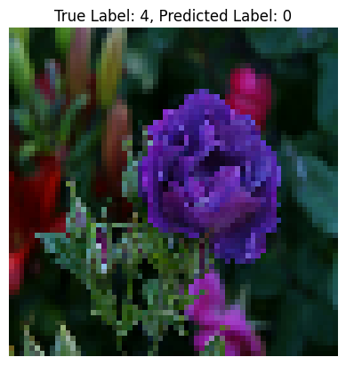

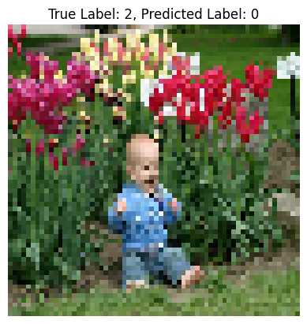

```python
import random
import matplotlib.pyplot as plt
import numpy as np
from sklearn.neighbors import KNeighborsClassifier

# Function to display random images along with true and predicted labels
def random_images_func(model, test_images, test_labels, num_images=5):
    # Select random indices from the test set
    random_indices = random.sample(range(len(test_images)), num_images)

    # Display each random image with true and predicted labels
    for idx in random_indices:
        # Get the random image and its true label
        random_image = test_images[idx]
        true_label = test_labels[idx]

        # Reshape the image for plotting
        image_shape = (64, 64, 3)  # Assuming images are RGB
        reshaped_image = np.reshape(random_image, image_shape)

        # Predict the label using the k-NN classifier
        predicted_label = model.predict([random_image])[0]

        # Display the image with true and predicted labels
        plt.imshow(reshaped_image)
        plt.title(f'True Label: {true_label}, Predicted Label: {predicted_label}')
        plt.axis('off')
        plt.show()

# Display five random images with true and predicted labels using final_knn_classifier
random_images_func(final_knn_classifier, test_images, test_labels, num_images=5)
```

## Extra Credit:

Consider the training set only for the questions below

# 1. Variable Selection (3 points):

Model 4: The next step in this analysis is feature selection of your own design. Feel free to choose between forward search, backward elimination and exhaustive search to implement variable selection. Choose a model that performs best and explain why.

Ans: Regarding variable selection, my preference would be backward elimination. This method starts with the entire feature set, providing the potential for more robust feature selection. Additionally, it is computationally less demanding compared to exhaustive search and avoids premature cessation, a drawback associated with forward search.

# 2.

Rebuild and report RMSE and MAE either model 3 or 4, but this time, instead of using a separate validation set, apply cross-validation on the train+validate set. Do you see any improvements? What do you observe with respect to performance when you compare using a validation set and cross validation? (3 points)

```python
import numpy as np
import matplotlib.pyplot as plt
from sklearn.linear_model import Lasso
from sklearn.model_selection import cross_val_score
from sklearn.model_selection import train_test_split
from sklearn.metrics import mean_squared_error

# Initialize lists to store RMSE values
rmse_values = []

#combining train and validation sets for cross validation
frames = [X_train, X_val]
frames2 = [y_train, y_val]
resultx = pd.concat(frames)
resulty = pd.concat(frames2)

lasso_reg = Lasso(alpha=1)
# Perform cross-validation to get RMSE
rmse_cv = np.sqrt(-cross_val_score(lasso_reg, resultx, resulty, scoring="neg_mean_squared_error", cv=5))
rmse_values.append(np.mean(rmse_cv))

print(rmse_values)
print("We observed that the RMSE value increased from 37.2 to 39.5")
```

```
[39.54532501823255]
We observed that the RMSE value increased from 37.2 to 39.5
```

# 3)

Among Model 1, 2, 3 and 4 which one would be your pick for future implementation? State your reasons. (1 points):

# 4.

If we fit a linear regression model using ordinary least squares, what will be the feature weights? Calculate the feature weights using the matrix form (do not use any built-in packages such as sklearn or stat models) (3 points)

```python
import numpy as np

# Calculate feature weights using OLS formula
X_transpose = np.transpose(X_train)
X_transpose_X_inv = np.linalg.inv(np.dot(X_transpose, X_train))
beta = np.dot(np.dot(X_transpose_X_inv, X_transpose), y_train)

print("Feature Weights (Coefficients):", beta)
```

```
Feature Weights (Coefficients): [-1.65009949e-01 -6.32844760e+02 -1.65079111e+01 -1.53132289e-02
 -1.53678736e+04 -6.81668913e+02  2.44012732e+02 -7.21649476e+02
  1.82588138e+04  1.87092651e+03  3.44413955e+02  7.76488523e+01
  1.00670272e+02  1.63370781e+02 -9.56687229e+02  1.65216692e+02
 -4.14530888e+01 -1.11952493e+02 -6.39341933e+00  1.51905922e+01
  2.22409325e+02 -4.90739540e+02 -5.78210128e+00 -3.77343248e+02
 -1.24830238e+00 -4.42384354e+02 -5.31797357e+01 -6.27541206e+02
 -2.65367176e+02  2.23188714e+02 -3.76774374e+02  1.02520997e+02
  1.13661389e+00  1.13248054e+02  1.66242474e+00  1.02589295e+00
 -1.17330623e+00  1.93930796e+02  1.69591899e+01 -2.36792505e+02
  3.08234568e+00 -1.00087870e-01 -9.08017246e-02 -1.54164522e-01
  8.62556676e-02  1.06382940e+01  8.51639333e-01  4.53876997e+00
  2.52565396e+00  1.30413890e+00 -1.43751245e+01 -9.20399035e+00
  4.43478595e+00  6.34497450e+00 -8.56886522e-01  3.16588220e-01
  1.81851912e+01 -4.64422252e-03 -2.27907779e+00  3.98187812e+00
  1.98713921e-02 -1.88609264e-02  2.15287909e-02  5.62162322e-02
  8.30605861e-02 -1.27934422e-01  2.23284640e-01 -3.60573444e+00
  5.62393093e-03  4.53171736e-03 -2.52883274e-01 -7.36518367e-01
  2.40364181e+00]
```